# Adult Children Caregivers Analysis

Anna Bokun

March 04, 2025

## Introduction

This document analyzes the characteristics of Mexican-American adult child caregivers from the Hispanic Established Populations for Epidemiologic Study of the Elderly (HEPESE) Wave 7 dataset (2010-2011). The analysis focuses specifically on adult children who provide care to their aging parents, examining different groups based on co-residence and household headship patterns.

## Methodology

We examine three distinct groups of adult children caregivers:

1. **Co-residing adult children caregivers**: Adult children who live in the same household as their parent care recipients
2. **Adult children who moved in with parents (general)**: Adult children who moved in with their parents without specifying caregiving as the primary reason
3. **Adult children who moved in for caregiving**: Adult children who moved in specifically to provide care to their parents

For each group, we analyze demographic characteristics, socioeconomic status, health status, caregiving intensity, and financial strain.

## Results

### Table 1: Characteristics of All Co-residing Adult Children Caregivers

All Co-residing Adult Children Caregivers (N = 191 )

| Characteristic | Category | n | % |
| --- | --- | --- | --- |
| Gender | Female | 123.00 | 64.4 |
| Gender | Male | 68.00 | 35.6 |
| Age group | Early Adulthood (18-44) | 19.00 | 9.9 |
| Age group | Early Retirement (65-75) | 23.00 | 12.0 |
| Age group | Late Middle Age (55-64) | 87.00 | 45.5 |
| Age group | Middle Age (45-54) | 62.00 | 32.5 |
| Education | Bachelor’s+ | 34.00 | 18.3 |
| Education | HS Graduate | 52.00 | 28.0 |
| Education | Less than HS | 71.00 | 38.2 |
| Education | Some College | 29.00 | 15.6 |
| Income | $10,000-$19,999 | 43.00 | 25.0 |
| Income | $20,000-$29,999 | 28.00 | 16.3 |
| Income | $30,000-$49,999 | 41.00 | 23.8 |
| Income | $50,000+ | 20.00 | 11.6 |
| Income | < $10,000 | 40.00 | 23.3 |
| Medicaid status | Not on Medicaid | 153.00 | 83.2 |
| Medicaid status | On Medicaid | 31.00 | 16.8 |
| Marital status | Married | 66.00 | 35.3 |
| Marital status | Not married | 121.00 | 64.7 |
| Health status | excellent/good | 102.00 | 53.7 |
| Health status | fair/poor | 88.00 | 46.3 |
| Financial strain | Has financial strain | 30.00 | 15.7 |
| Financial strain | No financial strain | 161.00 | 84.3 |
| Caregiving intensity | High intensity | 97.00 | 55.4 |
| Caregiving intensity | Low intensity | 10.00 | 5.7 |
| Caregiving intensity | Moderate intensity | 68.00 | 38.9 |
| Household headship | Head of household | 60.00 | 31.4 |
| Household headship | Not head of household | 131.00 | 68.6 |
| Caregiving hours | Mean ADL hours/day | 6.29 | NA |
| Caregiving hours | Mean IADL hours/day | 6.21 | NA |
| Parent cognitive status | Parent does not have dementia | 109.00 | 57.1 |
| Parent cognitive status | Parent has dementia | 82.00 | 42.9 |

Note:  
Data source: HEPESE Wave 7 (2010-2011)

### Table 2: Characteristics of Adult Children Who Moved In with Parents (General)

Adult Children Who Moved In with Parents - General (N = 21 )

| Characteristic | Category | n | % |
| --- | --- | --- | --- |
| Gender | Female | 18.00 | 85.7 |
| Gender | Male | 3.00 | 14.3 |
| Age group | Late Middle Age (55-64) | 12.00 | 57.1 |
| Age group | Middle Age (45-54) | 9.00 | 42.9 |
| Education | Bachelor’s+ | 3.00 | 14.3 |
| Education | HS Graduate | 6.00 | 28.6 |
| Education | Less than HS | 6.00 | 28.6 |
| Education | Some College | 6.00 | 28.6 |
| Income | $10,000-$19,999 | 7.00 | 36.8 |
| Income | $20,000-$29,999 | 5.00 | 26.3 |
| Income | $30,000-$49,999 | 6.00 | 31.6 |
| Income | $50,000+ | 1.00 | 5.3 |
| Medicaid status | Not on Medicaid | 15.00 | 78.9 |
| Medicaid status | On Medicaid | 4.00 | 21.1 |
| Marital status | Married | 8.00 | 38.1 |
| Marital status | Not married | 13.00 | 61.9 |
| Health status | excellent/good | 14.00 | 66.7 |
| Health status | fair/poor | 7.00 | 33.3 |
| Financial strain | No financial strain | 21.00 | 100.0 |
| Caregiving intensity | High intensity | 9.00 | 60.0 |
| Caregiving intensity | Low intensity | 1.00 | 6.7 |
| Caregiving intensity | Moderate intensity | 5.00 | 33.3 |
| Household headship | Head of household | 12.00 | 57.1 |
| Household headship | Not head of household | 9.00 | 42.9 |
| Caregiving hours | Mean ADL hours/day | 9.46 | NA |
| Caregiving hours | Mean IADL hours/day | 6.11 | NA |
| Parent cognitive status | Parent does not have dementia | 12.00 | 57.1 |
| Parent cognitive status | Parent has dementia | 9.00 | 42.9 |

Note:  
Data source: HEPESE Wave 7 (2010-2011)

### Table 3: Characteristics of Adult Children Who Moved In for Caregiving

Adult Children Who Moved In for Caregiving (N = 27 )

| Characteristic | Category | n | % |
| --- | --- | --- | --- |
| Gender | Female | 20.00 | 74.1 |
| Gender | Male | 7.00 | 25.9 |
| Age group | Early Adulthood (18-44) | 1.00 | 3.7 |
| Age group | Early Retirement (65-75) | 1.00 | 3.7 |
| Age group | Late Middle Age (55-64) | 15.00 | 55.6 |
| Age group | Middle Age (45-54) | 10.00 | 37.0 |
| Education | Bachelor’s+ | 6.00 | 23.1 |
| Education | HS Graduate | 6.00 | 23.1 |
| Education | Less than HS | 6.00 | 23.1 |
| Education | Some College | 8.00 | 30.8 |
| Income | $10,000-$19,999 | 6.00 | 30.0 |
| Income | $20,000-$29,999 | 3.00 | 15.0 |
| Income | $30,000-$49,999 | 6.00 | 30.0 |
| Income | $50,000+ | 1.00 | 5.0 |
| Income | < $10,000 | 4.00 | 20.0 |
| Medicaid status | Not on Medicaid | 24.00 | 88.9 |
| Medicaid status | On Medicaid | 3.00 | 11.1 |
| Marital status | Married | 14.00 | 53.8 |
| Marital status | Not married | 12.00 | 46.2 |
| Health status | excellent/good | 17.00 | 63.0 |
| Health status | fair/poor | 10.00 | 37.0 |
| Financial strain | Has financial strain | 6.00 | 22.2 |
| Financial strain | No financial strain | 21.00 | 77.8 |
| Caregiving intensity | High intensity | 18.00 | 69.2 |
| Caregiving intensity | Moderate intensity | 8.00 | 30.8 |
| Household headship | Head of household | 4.00 | 14.8 |
| Household headship | Not head of household | 23.00 | 85.2 |
| Caregiving hours | Mean ADL hours/day | 8.05 | NA |
| Caregiving hours | Mean IADL hours/day | 8.04 | NA |
| Parent cognitive status | Parent does not have dementia | 15.00 | 55.6 |
| Parent cognitive status | Parent has dementia | 12.00 | 44.4 |

Note:  
Data source: HEPESE Wave 7 (2010-2011)

## Comparing Financial Strain Across Groups

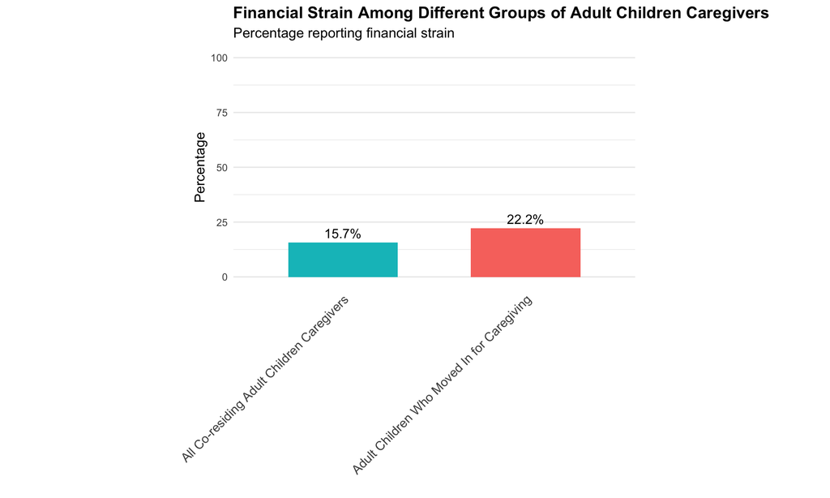

## Comparing Caregiving Hours Across Groups

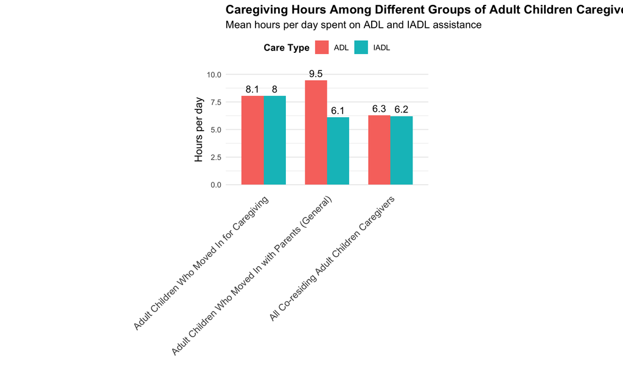

## Discussion

This analysis reveals several important patterns among adult children caregivers:

1. **Financial strain:** Adult children who moved in specifically for caregiving reasons experience higher rates of financial strain compared to caregivers who co-reside without discerning who moved in with whom (i.e., Table 1) (22.2% vs 15.7%).
2. **Caregiving intensity:** The data shows variation in caregiving intensity across different groups. Those who moved in specifically for caregiving spent more hours on caregiving tasks, relative to caregivers who co-reside without discerning who moved in with whom (8.04-8.05 ADL/IADL hours vs 6.21-6.29 ADL/IADL hours).
3. **Demographic differences:** There are notable demographic differences between adult children who moved in specifically for caregiving versus those who co-reside for other reasons, particularly in terms of gender distribution, marital status, and economic resources. For example, 11.1% of adult children who moved in for caregiving reasons report participating in Medicaid, vs 21.1% who moved in more generally, and 16.8% for those who co-reside without discerning who moved in with whom.
4. **Household headship:** Among adult children who moved in specifically for caregiving reasons, 85.2% are not the HOH vs 42.9% for adult children who moved in for general reasons. The pattern of household headship varies across groups, which may have implications for financial decision-making, resource allocation, and caregiver autonomy within the household.

## Limitations

Several limitations should be noted when interpreting these results:

1. The data is cross-sectional, limiting our ability to conduct analyses over time and to establish causal relationships between co-residence patterns and financial strain.
2. The sample sizes for some subgroups are prohibitively small (n < 30), which affects the reliability of estimates.
3. The HEPESE data is specific to Mexican-Americans in southwestern states and may not generalize to other Latino populations or regions.
4. Self-reported measures of financial strain and living arrangements may be subject to recall bias or social desirability effects.